# MAHANTESH_NK_DE_GRADED_MICROPROJECT

```python
import findspark
```

```python
!whereis spark
```

```
spark: /usr/local/spark
```

```python
findspark.init('/usr/local/spark')
```

```python
import pyspark
```

```python
from pyspark.sql import SparkSession
```

```python
ss = SparkSession.builder.appName('mt_car_analysis').getOrCreate()
```

```python
df1 = ss.read.csv('mtcars.csv',header = True,inferSchema = True)
```

```python
df1.printSchema()
```

```
root
 |-- _c0: string (nullable = true)
 |-- mpg: double (nullable = true)
 |-- cyl: integer (nullable = true)
 |-- disp: double (nullable = true)
 |-- hp: integer (nullable = true)
 |-- drat: double (nullable = true)
 |-- wt: double (nullable = true)
 |-- qsec: double (nullable = true)
 |-- vs: integer (nullable = true)
 |-- am: integer (nullable = true)
 |-- gear: integer (nullable = true)
 |-- carb: integer (nullable = true)
```

```python
df1.head(10)
```

```
[Row(_c0='Mazda RX4', mpg=21.0, cyl=6, disp=160.0, hp=110, drat=3.9, wt=2.62, qsec=16.46, vs=0, am=1, gear=4, carb=4),
 Row(_c0='Mazda RX4 Wag', mpg=21.0, cyl=6, disp=160.0, hp=110, drat=3.9, wt=2.875, qsec=17.02, vs=0, am=1, gear=4, carb=4),
 Row(_c0='Datsun 710', mpg=22.8, cyl=4, disp=108.0, hp=93, drat=3.85, wt=2.32, qsec=18.61, vs=1, am=1, gear=4, carb=1),
 Row(_c0='Hornet 4 Drive', mpg=21.4, cyl=6, disp=258.0, hp=110, drat=3.08, wt=3.215, qsec=19.44, vs=1, am=0, gear=3, carb=1),
 Row(_c0='Hornet Sportabout', mpg=18.7, cyl=8, disp=360.0, hp=175, drat=3.15, wt=3.44, qsec=17.02, vs=0, am=0, gear=3, carb=2),
 Row(_c0='Valiant', mpg=18.1, cyl=6, disp=225.0, hp=105, drat=2.76, wt=3.46, qsec=20.22, vs=1, am=0, gear=3, carb=1),
 Row(_c0='Duster 360', mpg=14.3, cyl=8, disp=360.0, hp=245, drat=3.21, wt=3.57, qsec=15.84, vs=0, am=0, gear=3, carb=4),
 Row(_c0='Merc 240D', mpg=24.4, cyl=4, disp=146.7, hp=62, drat=3.69, wt=3.19, qsec=20.0, vs=1, am=0, gear=4, carb=2),
 Row(_c0='Merc 230', mpg=22.8, cyl=4, disp=140.8, hp=95, drat=3.92, wt=3.15, qsec=22.9, vs=1, am=0, gear=4, carb=2),
 Row(_c0='Merc 280', mpg=19.2, cyl=6, disp=167.6, hp=123, drat=3.92, wt=3.44, qsec=18.3, vs=1, am=0, gear=4, carb=4)]
```

```python
df1.describe().show()
```

```
+-------+-----------+------------------+------------------+------------------+-----------------+------------------+------------------+------------------+------------------+-------------------+------------------+------------------+
|summary|        _c0|               mpg|               cyl|              disp|               hp|              drat|                wt|              qsec|                vs|                 am|              gear|              carb|
+-------+-----------+------------------+------------------+------------------+-----------------+------------------+------------------+------------------+------------------+-------------------+------------------+------------------+
|  count|         32|                32|                32|                32|               32|                32|                32|                32|                32|                 32|                32|                32|
|   mean|       null|20.090624999999996|            6.1875|230.72187500000004|         146.6875|3.5965625000000006|3.2172499999999995|17.848750000000003|            0.4375|            0.40625|            3.6875|            2.8125|
| stddev|       null| 6.026948052089103|1.7859216469465444|123.93869383138195|68.56286848932059|0.5346787360709716|0.9784574429896968|1.7869432360968436|0.5040161287741853|0.49899091723584604|0.7378040652569471|1.6151999776318522|
|    min|AMC Javelin|              10.4|                 4|              71.1|               52|              2.76|             1.513|              14.5|                 0|                  0|                 3|                 1|
|    max| Volvo 142E|              33.9|                 8|             472.0|              335|              4.93|             5.424|              22.9|                 1|                  1|                 5|                 8|
+-------+-----------+------------------+------------------+------------------+-----------------+------------------+------------------+------------------+------------------+-------------------+------------------+------------------+
```

```python
df1.mpg
```

```
<bound method _unary_op.<locals>._ of Column<b'mpg'>>
```

```python
panda_df=df1.toPandas()
```

```python
import matplotlib.pyplot as plt
```

```python
coor = df1.toPandas().corr()
sns.heatmap
```

```python
panda_df
```

|  | _c0 | mpg | cyl | disp | hp | drat | wt | qsec | vs | am | gear | carb |
| --- | --- | --- | --- | --- | --- | --- | --- | --- | --- | --- | --- | --- |
| 0 | Mazda RX4 | 21.0 | 6 | 160.0 | 110 | 3.90 | 2.620 | 16.46 | 0 | 1 | 4 | 4 |
| 1 | Mazda RX4 Wag | 21.0 | 6 | 160.0 | 110 | 3.90 | 2.875 | 17.02 | 0 | 1 | 4 | 4 |
| 2 | Datsun 710 | 22.8 | 4 | 108.0 | 93 | 3.85 | 2.320 | 18.61 | 1 | 1 | 4 | 1 |
| 3 | Hornet 4 Drive | 21.4 | 6 | 258.0 | 110 | 3.08 | 3.215 | 19.44 | 1 | 0 | 3 | 1 |
| 4 | Hornet Sportabout | 18.7 | 8 | 360.0 | 175 | 3.15 | 3.440 | 17.02 | 0 | 0 | 3 | 2 |
| 5 | Valiant | 18.1 | 6 | 225.0 | 105 | 2.76 | 3.460 | 20.22 | 1 | 0 | 3 | 1 |
| 6 | Duster 360 | 14.3 | 8 | 360.0 | 245 | 3.21 | 3.570 | 15.84 | 0 | 0 | 3 | 4 |
| 7 | Merc 240D | 24.4 | 4 | 146.7 | 62 | 3.69 | 3.190 | 20.00 | 1 | 0 | 4 | 2 |
| 8 | Merc 230 | 22.8 | 4 | 140.8 | 95 | 3.92 | 3.150 | 22.90 | 1 | 0 | 4 | 2 |
| 9 | Merc 280 | 19.2 | 6 | 167.6 | 123 | 3.92 | 3.440 | 18.30 | 1 | 0 | 4 | 4 |
| 10 | Merc 280C | 17.8 | 6 | 167.6 | 123 | 3.92 | 3.440 | 18.90 | 1 | 0 | 4 | 4 |
| 11 | Merc 450SE | 16.4 | 8 | 275.8 | 180 | 3.07 | 4.070 | 17.40 | 0 | 0 | 3 | 3 |
| 12 | Merc 450SL | 17.3 | 8 | 275.8 | 180 | 3.07 | 3.730 | 17.60 | 0 | 0 | 3 | 3 |
| 13 | Merc 450SLC | 15.2 | 8 | 275.8 | 180 | 3.07 | 3.780 | 18.00 | 0 | 0 | 3 | 3 |
| 14 | Cadillac Fleetwood | 10.4 | 8 | 472.0 | 205 | 2.93 | 5.250 | 17.98 | 0 | 0 | 3 | 4 |
| 15 | Lincoln Continental | 10.4 | 8 | 460.0 | 215 | 3.00 | 5.424 | 17.82 | 0 | 0 | 3 | 4 |
| 16 | Chrysler Imperial | 14.7 | 8 | 440.0 | 230 | 3.23 | 5.345 | 17.42 | 0 | 0 | 3 | 4 |
| 17 | Fiat 128 | 32.4 | 4 | 78.7 | 66 | 4.08 | 2.200 | 19.47 | 1 | 1 | 4 | 1 |
| 18 | Honda Civic | 30.4 | 4 | 75.7 | 52 | 4.93 | 1.615 | 18.52 | 1 | 1 | 4 | 2 |
| 19 | Toyota Corolla | 33.9 | 4 | 71.1 | 65 | 4.22 | 1.835 | 19.90 | 1 | 1 | 4 | 1 |
| 20 | Toyota Corona | 21.5 | 4 | 120.1 | 97 | 3.70 | 2.465 | 20.01 | 1 | 0 | 3 | 1 |
| 21 | Dodge Challenger | 15.5 | 8 | 318.0 | 150 | 2.76 | 3.520 | 16.87 | 0 | 0 | 3 | 2 |
| 22 | AMC Javelin | 15.2 | 8 | 304.0 | 150 | 3.15 | 3.435 | 17.30 | 0 | 0 | 3 | 2 |
| 23 | Camaro Z28 | 13.3 | 8 | 350.0 | 245 | 3.73 | 3.840 | 15.41 | 0 | 0 | 3 | 4 |
| 24 | Pontiac Firebird | 19.2 | 8 | 400.0 | 175 | 3.08 | 3.845 | 17.05 | 0 | 0 | 3 | 2 |
| 25 | Fiat X1-9 | 27.3 | 4 | 79.0 | 66 | 4.08 | 1.935 | 18.90 | 1 | 1 | 4 | 1 |
| 26 | Porsche 914-2 | 26.0 | 4 | 120.3 | 91 | 4.43 | 2.140 | 16.70 | 0 | 1 | 5 | 2 |
| 27 | Lotus Europa | 30.4 | 4 | 95.1 | 113 | 3.77 | 1.513 | 16.90 | 1 | 1 | 5 | 2 |
| 28 | Ford Pantera L | 15.8 | 8 | 351.0 | 264 | 4.22 | 3.170 | 14.50 | 0 | 1 | 5 | 4 |
| 29 | Ferrari Dino | 19.7 | 6 | 145.0 | 175 | 3.62 | 2.770 | 15.50 | 0 | 1 | 5 | 6 |
| 30 | Maserati Bora | 15.0 | 8 | 301.0 | 335 | 3.54 | 3.570 | 14.60 | 0 | 1 | 5 | 8 |
| 31 | Volvo 142E | 21.4 | 4 | 121.0 | 109 | 4.11 | 2.780 | 18.60 | 1 | 1 | 4 | 2 |

```python
#checking the info about features in dataframe
panda_df.info()
```

```
<class 'pandas.core.frame.DataFrame'>
RangeIndex: 32 entries, 0 to 31
Data columns (total 12 columns):
_c0     32 non-null object
mpg     32 non-null float64
cyl     32 non-null int64
disp    32 non-null float64
hp      32 non-null int64
drat    32 non-null float64
wt      32 non-null float64
qsec    32 non-null float64
vs      32 non-null int64
am      32 non-null int64
gear    32 non-null int64
carb    32 non-null int64
dtypes: float64(5), int64(6), object(1)
memory usage: 3.1+ KB
```

```python
# summery of stats in dataframe
panda_df.describe()
```

|  | mpg | cyl | disp | hp | drat | wt | qsec | vs | am | gear | carb |
| --- | --- | --- | --- | --- | --- | --- | --- | --- | --- | --- | --- |
| count | 32.000000 | 32.000000 | 32.000000 | 32.000000 | 32.000000 | 32.000000 | 32.000000 | 32.000000 | 32.000000 | 32.000000 | 32.0000 |
| mean | 20.090625 | 6.187500 | 230.721875 | 146.687500 | 3.596563 | 3.217250 | 17.848750 | 0.437500 | 0.406250 | 3.687500 | 2.8125 |
| std | 6.026948 | 1.785922 | 123.938694 | 68.562868 | 0.534679 | 0.978457 | 1.786943 | 0.504016 | 0.498991 | 0.737804 | 1.6152 |
| min | 10.400000 | 4.000000 | 71.100000 | 52.000000 | 2.760000 | 1.513000 | 14.500000 | 0.000000 | 0.000000 | 3.000000 | 1.0000 |
| 25% | 15.425000 | 4.000000 | 120.825000 | 96.500000 | 3.080000 | 2.581250 | 16.892500 | 0.000000 | 0.000000 | 3.000000 | 2.0000 |
| 50% | 19.200000 | 6.000000 | 196.300000 | 123.000000 | 3.695000 | 3.325000 | 17.710000 | 0.000000 | 0.000000 | 4.000000 | 2.0000 |
| 75% | 22.800000 | 8.000000 | 326.000000 | 180.000000 | 3.920000 | 3.610000 | 18.900000 | 1.000000 | 1.000000 | 4.000000 | 4.0000 |
| max | 33.900000 | 8.000000 | 472.000000 | 335.000000 | 4.930000 | 5.424000 | 22.900000 | 1.000000 | 1.000000 | 5.000000 | 8.0000 |

```python
# dropping unwanted column in panda_df
panda_df.drop('_c0' , axis = 1,inplace = True)
```

```python
panda_df.head(5)
```

|  | mpg | cyl | disp | hp | drat | wt | qsec | vs | am | gear | carb |
| --- | --- | --- | --- | --- | --- | --- | --- | --- | --- | --- | --- |
| 0 | 21.0 | 6 | 160.0 | 110 | 3.90 | 2.620 | 16.46 | 0 | 1 | 4 | 4 |
| 1 | 21.0 | 6 | 160.0 | 110 | 3.90 | 2.875 | 17.02 | 0 | 1 | 4 | 4 |
| 2 | 22.8 | 4 | 108.0 | 93 | 3.85 | 2.320 | 18.61 | 1 | 1 | 4 | 1 |
| 3 | 21.4 | 6 | 258.0 | 110 | 3.08 | 3.215 | 19.44 | 1 | 0 | 3 | 1 |
| 4 | 18.7 | 8 | 360.0 | 175 | 3.15 | 3.440 | 17.02 | 0 | 0 | 3 | 2 |

```python
# checking null values
panda_df.isnull().sum()
```

[output not shown]

#### as we can see, there are no null values present in data

```python
panda_df.duplicated().sum()
```

```
0
```

#### Above code describes that no data is duplicated in dataframe and all are unique values

#### As we are mainly focusing on automatic car and manual car in "am" columns. lets analyse the data on the basis of that

```python
panda_df.am.value_counts()
```

```
0    19
1    13
Name: am, dtype: int64
```

#### considering the transmission type : 0 for autoamatic and 1 for manual

#### it clearly states above that 19 rows are of automatic and 13 cars are of manual transmission tyep

```python
import seaborn as sns
```

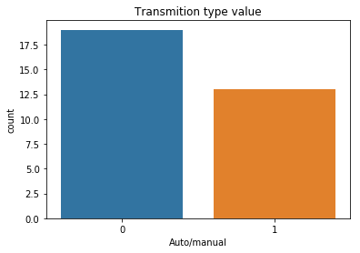

```python
sns.barplot(x = panda_df['am'].value_counts().index , y = panda_df['am'].value_counts())
plt.title('Transmition type value')
plt.xlabel('Auto/manual')
plt.ylabel('count')
```

```python
panda_df.groupby('am')['mpg'].value_counts().unstack()
```

| mpg am | 10.4 | 13.3 | 14.3 | 14.7 | 15.0 | 15.2 | 15.5 | 15.8 | 16.4 | 17.3 | ... | 21.0 | 21.4 | 21.5 | 22.8 | 24.4 | 26.0 | 27.3 | 30.4 | 32.4 | 33.9 |
| --- | --- | --- | --- | --- | --- | --- | --- | --- | --- | --- | --- | --- | --- | --- | --- | --- | --- | --- | --- | --- | --- |
| 0 | 2.0 | 1.0 | 1.0 | 1.0 | NaN | 2.0 | 1.0 | NaN | 1.0 | 1.0 | ... | NaN | 1.0 | 1.0 | 1.0 | 1.0 | NaN | NaN | NaN | NaN | NaN |
| 1 | NaN | NaN | NaN | NaN | 1.0 | NaN | NaN | 1.0 | NaN | NaN | ... | 2.0 | 1.0 | NaN | 1.0 | NaN | 1.0 | 1.0 | 2.0 | 1.0 | 1.0 |

2 rows × 25 columns

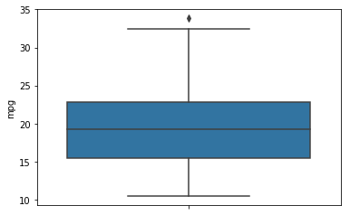

```python
sns.boxplot(panda_df.mpg , orient= "v")
```

#### since the outlier is found in the mpg column but as the data is already consist of very less number of rows , we are not dopping it for better model performance

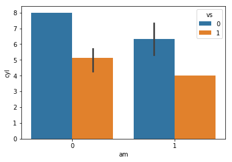

```python
sns.barplot(x = panda_df.am , y = panda_df.cyl, hue = panda_df.vs)
```

```python
panda_df.info()
```

```
<class 'pandas.core.frame.DataFrame'>
RangeIndex: 32 entries, 0 to 31
Data columns (total 11 columns):
mpg     32 non-null float64
cyl     32 non-null int64
disp    32 non-null float64
hp      32 non-null int64
drat    32 non-null float64
wt      32 non-null float64
qsec    32 non-null float64
vs      32 non-null int64
am      32 non-null int64
gear    32 non-null int64
carb    32 non-null int64
dtypes: float64(5), int64(6)
memory usage: 2.8 KB
```

### as we can see , above all the columns are already in numerical form , we are good to for model buidling.

#### on the basis of above lets build the model for predicting whether car model is automatic or manual in pyspark

```python
# from pyspark.ml.linalg import Vectors
from pyspark.ml.feature import VectorAssembler
from pyspark.ml.classification import LogisticRegression
from pyspark.ml.evaluation import BinaryClassificationEvaluator
```

```python
df_car = df1.drop('_c0')
```

```python
df_car.columns
```

```
['mpg', 'cyl', 'disp', 'hp', 'drat', 'wt', 'qsec', 'vs', 'am', 'gear', 'carb']
```

```python
feature_col = df_car['mpg','cyl','disp','hp','drat','wt','qsec','vs','gear','carb']
```

```python
assemblr = VectorAssembler(inputCols = ['mpg','cyl','disp','hp','drat','wt','qsec','vs','gear','carb'],outputCol='Features')
```

```python
output = assemblr.transform(df_car)
```

```python
output.columns
```

```
['mpg',
 'cyl',
 'disp',
 'hp',
 'drat',
 'wt',
 'qsec',
 'vs',
 'am',
 'gear',
 'carb',
 'Features']
```

```python
final_df = output.select("Features","am")
```

```python
final_df.columns
```

```
['Features', 'am']
```

```python
final_df.show()
```

```
+--------------------+---+
|            Features| am|
+--------------------+---+
|[21.0,6.0,160.0,1...|  1|
|[21.0,6.0,160.0,1...|  1|
|[22.8,4.0,108.0,9...|  1|
|[21.4,6.0,258.0,1...|  0|
|[18.7,8.0,360.0,1...|  0|
|[18.1,6.0,225.0,1...|  0|
|[14.3,8.0,360.0,2...|  0|
|[24.4,4.0,146.7,6...|  0|
|[22.8,4.0,140.8,9...|  0|
|[19.2,6.0,167.6,1...|  0|
|[17.8,6.0,167.6,1...|  0|
|[16.4,8.0,275.8,1...|  0|
|[17.3,8.0,275.8,1...|  0|
|[15.2,8.0,275.8,1...|  0|
|[10.4,8.0,472.0,2...|  0|
|[10.4,8.0,460.0,2...|  0|
|[14.7,8.0,440.0,2...|  0|
|[32.4,4.0,78.7,66...|  1|
|[30.4,4.0,75.7,52...|  1|
|[33.9,4.0,71.1,65...|  1|
+--------------------+---+
only showing top 20 rows
```

### dividing the data into train and test data

```python
train_df,test_df = final_df.randomSplit([0.8,0.2],seed = 42)
```

```python
train_df.count()
```

```
27
```

```python
test_df.count()
```

```
5
```

```python
train_df.show(27)
```

```
+--------------------+---+
|            Features| am|
+--------------------+---+
|[10.4,8.0,460.0,2...|  0|
|[14.7,8.0,440.0,2...|  0|
|[15.0,8.0,301.0,3...|  1|
|[15.2,8.0,275.8,1...|  0|
|[15.2,8.0,304.0,1...|  0|
|[15.5,8.0,318.0,1...|  0|
|[15.8,8.0,351.0,2...|  1|
|[16.4,8.0,275.8,1...|  0|
|[17.3,8.0,275.8,1...|  0|
|[17.8,6.0,167.6,1...|  0|
|[18.7,8.0,360.0,1...|  0|
|[19.2,6.0,167.6,1...|  0|
|[19.7,6.0,145.0,1...|  1|
|[21.0,6.0,160.0,1...|  1|
|[21.0,6.0,160.0,1...|  1|
|[21.4,4.0,121.0,1...|  1|
|[21.4,6.0,258.0,1...|  0|
|[21.5,4.0,120.1,9...|  0|
|[22.8,4.0,108.0,9...|  1|
|[22.8,4.0,140.8,9...|  0|
|[24.4,4.0,146.7,6...|  0|
|[26.0,4.0,120.3,9...|  1|
|[27.3,4.0,79.0,66...|  1|
|[30.4,4.0,75.7,52...|  1|
|[30.4,4.0,95.1,11...|  1|
|[32.4,4.0,78.7,66...|  1|
|[33.9,4.0,71.1,65...|  1|
+--------------------+---+
```

```python
test_df.show(5)
```

```
+--------------------+---+
|            Features| am|
+--------------------+---+
|[10.4,8.0,472.0,2...|  0|
|[13.3,8.0,350.0,2...|  0|
|[14.3,8.0,360.0,2...|  0|
|[18.1,6.0,225.0,1...|  0|
|[19.2,8.0,400.0,1...|  0|
+--------------------+---+
```

```python
#### Since the above test data shows , only singular category data so shuffle the data again.
```

[output not shown]

[output not shown]

```python
Lr = LogisticRegression(featuresCol='Features',labelCol='am')
```

```python
lr_model = Lr.fit(train_df)
```

```python
pred_lg1 = lr_model.evaluate(test_df)
```

```python
evaluator = BinaryClassificationEvaluator(labelCol='am')
```

```python
accuracy = evaluator.evaluate(pred_val)
```

```python
print('accuracy',accuracy)
```

[output not shown]

### Using the another model for evaluation

```python
from pyspark.ml.classification import DecisionTreeClassifier
```

```python
dc = DecisionTreeClassifier(featuresCol='Features',labelCol='am')
```

```python
dc_model = dc.fit(train_df)
```

```python
pred_val_dc = dc_model.transform(test_df)
```

```python
eva = BinaryClassificationEvaluator(labelCol='am')
```

```python
acc_dc = eva.evaluate(pred_val_dc)
```

```python
print("accuracy_of_dc",acc_dc)
```

```
accuracy_of_dc 0.0
```